# How Do Casual and Member Riders Differ?

Yeongjin Yu

2025-09-26

# Section 1: Introduction

This report investigates rider behaviour in New York City’s Citi Bike system by comparing usage patterns between casual and member riders. Using a sample of 50,000 trips, we examine ride durations, bike type preferences, and time-of-day usage to identify behavioural differences. Understanding these behavioural differences can help Citi Bike enhance service delivery, allocate resources effectively, and design targeted engagement strategies.

The analysis is guided by three research questions: 1. Do casual riders take longer trips than members? 2. How does bike type usage differ between these two groups? 3. Are there differences in ride durations by time of day across user types?

To answer these questions, a random sample of 50,000 trips was drawn from the Citi Bike dataset. The key variables explored include:

- **ride_duration**: a quantitative measure of how long each trip lasted (in minutes),
- **bike_type**: a categorical variable indicating whether the bike was classic, electric, or docked,
- **day_period**: a categorical variable indicating whether the ride occurred in the morning, afternoon, or night.

This report uses descriptive statistics, data visualisation, and comparison techniques to uncover user patterns relevant to Citi Bike’s operations.

# Section 2: Data Cleaning

The original dataset includes multiple bike duration columns and geographic identifiers that are not relevant to our research aims. The following steps were used to clean and reshape the data for analysis.

```r
# Load libraries
library(tidyverse)

# Import data
data <- read_csv("Citi-Bike-NYC.csv")

# Preview the data
head(data)
```

```
## # A tibble: 6 × 16
##   ride_id          started_at          ended_at            start_station_name
##   <chr>            <dttm>              <dttm>              <chr>
## 1 159C90AB46D5631B 2023-04-01 17:24:06 2023-04-01 17:46:10 Hoyt St & Warren St
## 2 4349D44670885CED 2023-04-13 15:09:12 2023-04-13 15:16:11 E 25 St & 2 Ave
## 3 55EB4E8AF45439D2 2023-04-28 15:17:00 2023-04-28 15:26:09 3 Ave & E 62 St
## 4 3133FC58AA938D08 2023-04-23 16:18:49 2023-04-23 17:10:50 Washington Pl & 6 Ave
## 5 BF2DD897668DA1AC 2023-04-21 15:42:08 2023-04-21 15:47:04 3 Ave & E 62 St
## 6 FF558338220E455B 2023-04-21 22:21:17 2023-04-21 22:26:53 Evergreen Ave & Noll…
## # ℹ 12 more variables: start_station_id <dbl>, end_station_name <chr>,
## #   end_station_id <chr>, start_lat <dbl>, start_lng <dbl>, end_lat <dbl>,
## #   end_lng <dbl>, member_casual <chr>, day_period <chr>, classic_bike <dbl>,
## #   electric_bike <dbl>, docked_bike <dbl>
```

We removed location and timestamp variables that were not required for the current study.

```r
# Drop unnecessary columns
data_clean <- data %>%
  select(-c(started_at, ended_at, start_station_id, end_station_id,
            start_lat, start_lng, end_lat, end_lng))
```

The dataset initially stores ride durations in separate columns for each bike type. We pivot these columns into long format, creating a single bike_type column and a single ride_duration column. This transformation ensures that each ride is represented by a single row, simplifying comparison across user types.

```r
# Pivot to long format and filter missing durations
data_long <- data_clean %>%
  pivot_longer(cols = c(classic_bike, electric_bike, docked_bike),
               names_to = "bike_type",
               values_to = "ride_duration") %>%
  filter(!is.na(ride_duration))
```

We selected the relevant columns for the analysis and verified the structure.

```r
# Select final analysis variables
data_final <- data_long %>%
  select(member_casual, day_period, bike_type, ride_duration)

# Preview cleaned data
head(data_final)
```

```
## # A tibble: 6 × 4
##   member_casual day_period bike_type     ride_duration
##   <chr>         <chr>      <chr>                 <dbl>
## 1 member        afternoon  classic_bike          22.1
## 2 member        afternoon  electric_bike          6.98
## 3 member        afternoon  electric_bike          9.15
## 4 member        afternoon  classic_bike          52.0
## 5 member        afternoon  classic_bike           4.93
## 6 member        night      electric_bike          5.6
```

```r
# Sample 50,000 rows using student ID as seed
set.seed(535543)
bike_sample <- data_final %>% sample_n(50000)

# Confirm sample size
nrow(bike_sample)
```

```
## [1] 50000
```

This dataset (bike_sample) is used for all further analysis.

# Section 3: Approximating the Distribution of Trip Durations

## Ride Duration Distribution

To understand the shape of the ride duration distribution, we compare the actual distribution to simulated data from both a uniform and a normal distribution with matching parameters. This helps identify a suitable approximation method for ride duration.

We first define a summary function.

```r
summary_stats <- function(x) {
  tibble(
    min = min(x),
    max = max(x),
    mean = mean(x),
    sd = sd(x),
    median = median(x),
    IQR = IQR(x)
  )
}
```

We then summarise the ride durations in our sample.

```r
summary_stats(bike_sample$ride_duration)
```

```
## # A tibble: 1 × 6
##     min   max  mean    sd median   IQR
##   <dbl> <dbl> <dbl> <dbl>  <dbl> <dbl>
## 1     0  59.9  12.9  11.0   9.37  11.8
```

Next, we simulate data from a uniform and normal distribution using the actual ride duration’s min/max and mean/sd respectively.

```r
# Simulate 50,000 ride durations
uniform_sample <- runif(50000,
                        min = min(bike_sample$ride_duration),
                        max = max(bike_sample$ride_duration))

normal_sample <- rnorm(50000,
                       mean = mean(bike_sample$ride_duration),
                       sd = sd(bike_sample$ride_duration))
```

We summarise the simulated distributions.

```r
summary_stats(uniform_sample)
```

```
## # A tibble: 1 × 6
##       min   max  mean    sd median   IQR
##     <dbl> <dbl> <dbl> <dbl>  <dbl> <dbl>
## 1 0.00105  59.9  29.9  17.3   29.7  30.0
```

```r
summary_stats(normal_sample)
```

```
## # A tibble: 1 × 6
##     min   max  mean    sd median   IQR
##   <dbl> <dbl> <dbl> <dbl>  <dbl> <dbl>
## 1 -33.6  58.1  12.9  10.9   12.9  14.8
```

Finally, we plot the three distributions side by side for comparison.

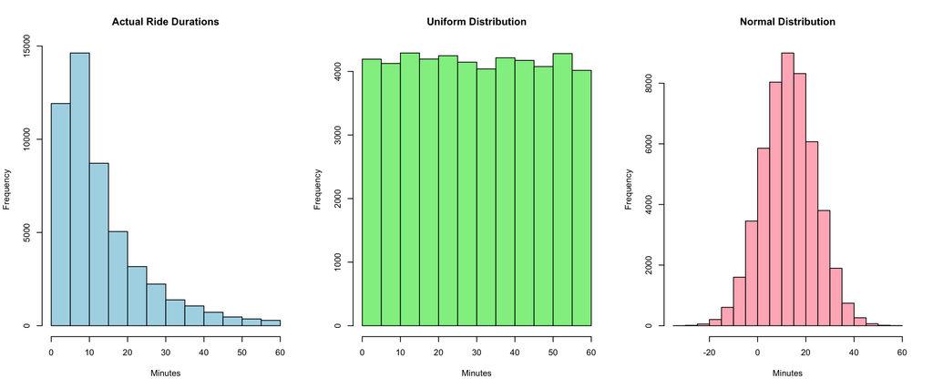

Figure 1: Comparison of Actual, Uniform, and Normal Distributions of Ride Duration

```r
par(mfrow = c(1, 3))  # Set up 3 side-by-side plots

hist(bike_sample$ride_duration,
     main = "Actual Ride Durations",
     col = "lightblue",
     xlab = "Minutes")

hist(uniform_sample,
     main = "Uniform Distribution",
     col = "lightgreen",
     xlab = "Minutes")

hist(normal_sample,
     main = "Normal Distribution",
     col = "lightpink",
     xlab = "Minutes")
```

The actual ride duration distribution is right-skewed with a high peak at short durations. The normal distribution approximates the centre better than the uniform distribution, which spreads values evenly. However, both simulated distributions fail to capture the skew and variability in the real data. Overall, the normal distribution provides a better—but still limited—approximation for ride durations.

# Section 4: Citi-Bike User Behaviour

This section compares key behaviours between casual and member riders using summary statistics, visualisations, and inferential tests.

## Ride Duration by User Type

We begin by comparing the ride durations of casual and member riders.

```r
# Summary statistics by user type
bike_sample %>%
  group_by(member_casual) %>%
  summarise(
    Mean = round(mean(ride_duration), 2),
    Median = round(median(ride_duration), 2),
    SD = round(sd(ride_duration), 2),
    Count = n()
  )
```

```
## # A tibble: 2 × 5
##   member_casual  Mean Median    SD Count
##   <chr>         <dbl>  <dbl> <dbl> <int>
## 1 casual         16.9  13.5   12.6  9401
## 2 member         12.0   8.65  10.3 40599
```

```r
# Perform t-test
t_test_result <- t.test(ride_duration ~ member_casual, data = bike_sample)
t_test_result$p.value
```

```
## [1] 4.543793e-258
```

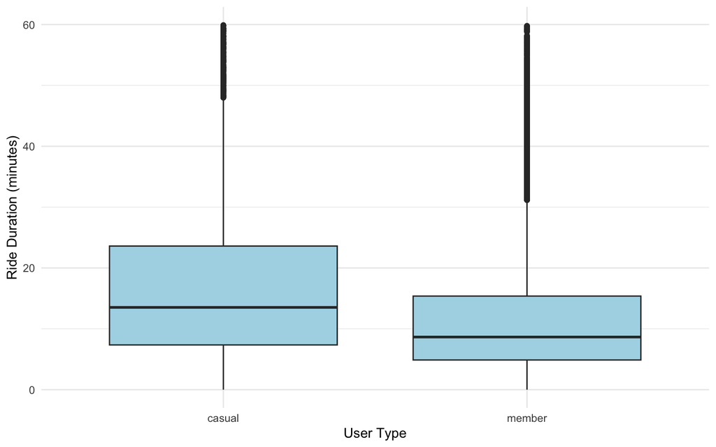

Figure 2: Ride Duration by User Type

```r
# Visualise ride duration
ggplot(bike_sample, aes(x = member_casual, y = ride_duration)) +
  geom_boxplot(fill = "lightblue") +
  labs(x = "User Type", y = "Ride Duration (minutes)") +
  theme_minimal()
```

Casual riders take longer trips on average than members. The t-test result (p < 0.001) confirms this difference is statistically significant. The boxplot also shows greater variability among casual users.

## Ride Duration Distribution by User Type

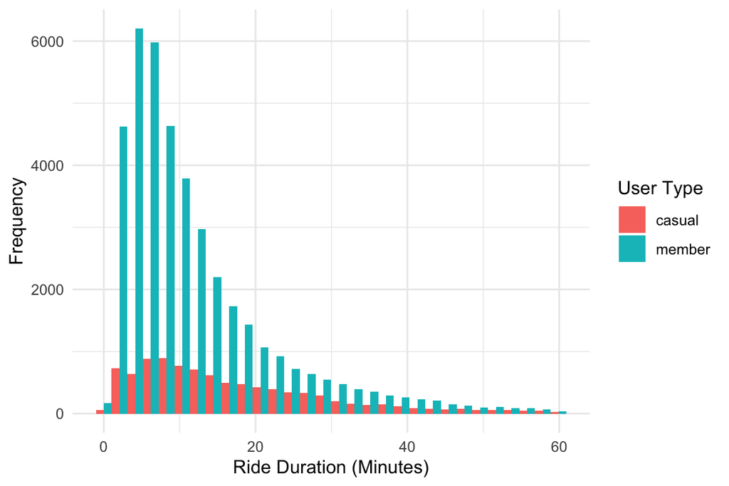

Figure 3: Ride Duration Distribution by User Type

```r
ggplot(bike_sample, aes(x = ride_duration, fill = member_casual)) +
  geom_histogram(position = "dodge", bins = 30) +
  labs(x = "Ride Duration (Minutes)",
       y = "Frequency",
       fill = "User Type") +
  theme_minimal()
```

Figure 3 presents the ride duration distribution by user type. Member rides are more concentrated in shorter durations, whereas casual rides are more spread out with a longer tail. This supports the earlier summary and confirms that casual riders tend to take longer trips.

## Bike Type Preference

Next, we examine which types of bikes each group tends to use.

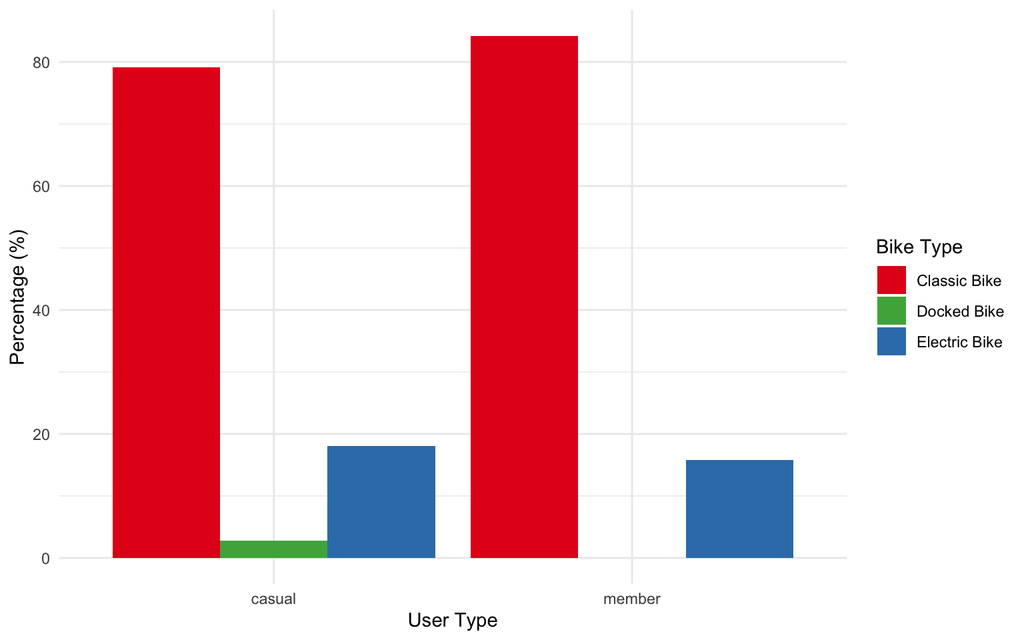

Figure 4: Bike Type Usage by User Type

```r
# Fill missing combinations
bike_type_summary <- bike_sample %>%
  count(member_casual, bike_type) %>%
  group_by(member_casual) %>%
  mutate(Proportion = round(n / sum(n) * 100, 2)) %>%
  ungroup() %>%
  complete(member_casual, bike_type, fill = list(n = 0, Proportion = 0))

# Plot with consistent bar widths
ggplot(bike_type_summary, aes(x = member_casual, y = Proportion, fill = bike_type)) +
  geom_bar(stat = "identity", position = "dodge") +
  labs(x = "User Type", y = "Percentage (%)", fill = "Bike Type") +
  scale_fill_manual(
    values = c("classic_bike" = "#E41A1C", "docked_bike" = "#4DAF4A", "electric_bike" = "#377EB8"),
    labels = c("classic_bike" = "Classic Bike",
               "docked_bike" = "Docked Bike",
               "electric_bike" = "Electric Bike")
  ) +
  theme_minimal()
```

Both groups mostly use classic bikes. However, casual riders show more diversity, using docked and electric bikes more often than members.

## Ride Duration by Day Period

We now explore how trip lengths vary by time of day.

```r
duration_by_period <- bike_sample %>%
  group_by(member_casual, day_period) %>%
  summarise(
    Mean_Duration = round(mean(ride_duration), 2),
    Count = n()
  )

duration_by_period
```

```
## # A tibble: 6 × 4
## # Groups:   member_casual [2]
##   member_casual day_period Mean_Duration Count
##   <chr>         <chr>              <dbl> <int>
## 1 casual        afternoon           18.2  4732
## 2 casual        morning             15.2  1711
## 3 casual        night               15.8  2958
## 4 member        afternoon           12.5 16796
## 5 member        morning             11.0 10929
## 6 member        night               12.0 12874
```

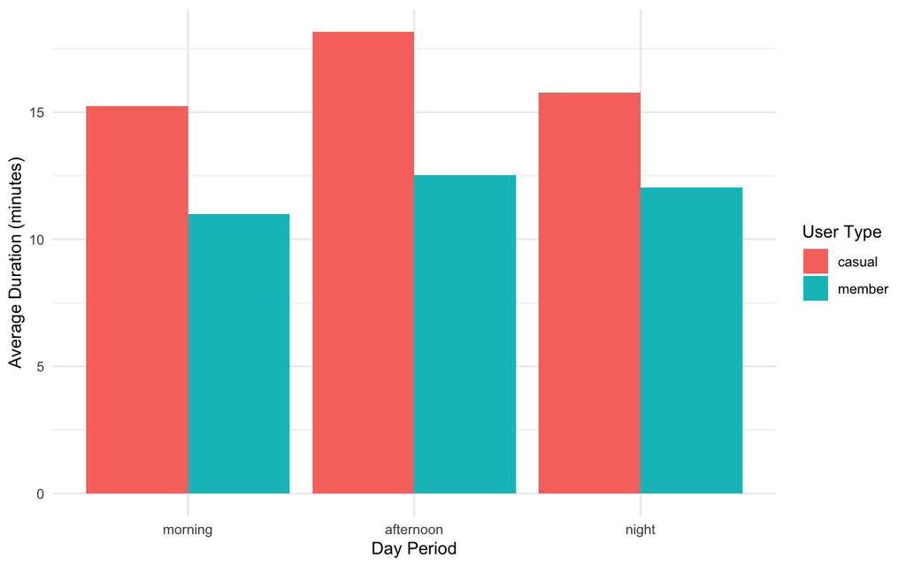

Figure 5: Average Ride Duration by Day Period and User Type

```r
# Reorder factor levels for day_period
duration_by_period$day_period <- factor(duration_by_period$day_period,
                                        levels = c("morning", "afternoon", "night"))

# Plot with correct order
ggplot(duration_by_period, aes(x = day_period, y = Mean_Duration, fill = member_casual)) +
  geom_bar(stat = "identity", position = "dodge") +
  labs(x = "Day Period", y = "Average Duration (minutes)", fill = "User Type") +
  theme_minimal()
```

Casual riders take longer rides than members across all time periods. Afternoon rides tend to be the longest for both groups.

# Section 5: Conclusion

This analysis examined whether casual riders use Citi Bikes differently from members, using a random sample of 50,000 rides. It revealed significant differences between casual and member riders, most notably in ride duration and bike type preferences. Casual riders consistently take longer trips across all day periods and demonstrate more diversity in bike selection, using electric and docked bikes more frequently than members. Although the dataset includes start and end locations, including coordinates and station names, it does not explicitly record trip purposes. The observed patterns hint at potential differences in usage, but further spatial analysis would be necessary to draw definitive conclusions about underlying travel motivations. The statistically significant variations in ride characteristics highlight the potential for targeted marketing strategies and customised membership plans that could better serve each user group’s unique needs.

## Summary of Findings

- **Ride Duration**: Casual riders take significantly longer trips than members.
- **Bike Type**: Both rider types mostly use classic bikes, but casual users show greater diversity, using electric and docked bikes more often than members.
- **Day Period Usage**: Casual riders ride for longer durations throughout the day, with a consistent pattern across morning, afternoon, and night periods.

## Implications

These behavioural differences suggest that Citi Bike could:

- Develop **targeted marketing** strategies to encourage casual riders to become members.
- Offer **customised membership plans** that reflect different usage patterns.
- Use usage data to optimise **bike type inventory and placement** across times and locations.

These insights can guide service improvements such as **optimising bike placement** and **targeting promotions** to convert casual riders into long-term members.

## Limitations

- The analysis was limited to a single random sample of 50,000 rides.
- Spatial and seasonal variation were not explored, although the dataset includes location and date variables.
- The analysis used basic visual and statistical tools, and did not include predictive modelling.

## Future Research Directions

Future work could:

- Investigate **spatial and seasonal patterns** in bike usage.
- Explore **factors that influence membership conversion**.
- Apply **machine learning models** to predict user behaviour and ride patterns.

Overall, this study highlights the value of data-driven approaches in improving shared transport systems and enhancing user experience.